# GSEA Null Calibration: Permutation vs Rotation (Walkthrough)

# 1 Overview

This document explains the main steps in `rotations.r`, runs the simulation script, and summarizes the differences between gene-wise permutation and rotation-based null generation.

The report is designed to rerun quickly:

- `rotations.r` now uses a simulation cache (`simulation_cache.rds`) for Monte Carlo outputs
- this R Markdown file also enables knitr chunk caching

If the cache does not exist (or configuration changes), the first run can still take a while.

# 2 What `rotations.r` Does (Step-by-Step)

## 2.1 1. Configuration

The script sets:

- dataset dimensions (`ngenes`, `nsamples`)
- gene set size (`set_size`, `set_idx`)
- Monte Carlo settings (`nsim`, `nperm`, `nrot`)
- correlation settings (`rho_set_grid`, `rho_bg`)
- parallelization mode (`parallel_over`, `ncores`)
- cache options (`use_simulation_cache`, `simulation_cache_file`)

## 2.2 2. Core helper functions

The script defines functions to:

- compute a GSEA-like enrichment score (`gsea_set_stat`)
- compute empirical right-tail p-values (`empirical_p_right`)
- simulate correlated noise in set and background genes
- simulate null datasets (no differential expression)
- fit limma and compute enrichment scores from p-values
- build a rotation basis from the null-model residual space
- sample random orthogonal rotations in that residual space

## 2.3 3. Null generation methods compared

For each simulated dataset, the script computes:

- **Permutation null**: shuffles gene-wise p-values before recomputing the set statistic
- **Rotation null**: rotates residuals under the null model, refits, and recomputes the set statistic

This is repeated over:

- multiple correlation strengths in `rho_set_grid`
- multiple Monte Carlo replicates (`nsim`)

## 2.4 4. Summaries and output files

The script then:

- summarizes empirical type-I error and mean p-values by `rho_set`
- writes CSV outputs
- creates diagnostic plots (calibration panel, ECDF, null histograms)
- creates correlation heatmaps and rotation-preservation diagnostics

# 3 Run the Script (Using Cached Simulation Data)

```r
if (!file.exists("rotations.r")) {
  stop("Cannot find rotations.r in the working directory.")
}

if (!file.exists("simulation_cache.rds")) {
  message("No simulation cache found yet. First run may be slow.")
}

sim_env <- new.env(parent = globalenv())
source("rotations.r", local = sim_env)
```

```
## Parallel mode: nsim | cores: 7
## Running rho_set = 0.00
## Running rho_set = 0.20
## Running rho_set = 0.40
## Running rho_set = 0.60
## Running rho_set = 0.80
## Saved simulation outputs to simulation_cache.rds
##
## Empirical type-I error (target = 0.05 ):
##   rho_set type1_perm type1_rot mean_p_perm mean_p_rot
## 1     0.0       0.11      0.04   0.4667864  0.4805788
## 2     0.2       0.15      0.03   0.4641517  0.4530539
## 3     0.4       0.23      0.05   0.5284631  0.4839920
## 4     0.6       0.40      0.05   0.4893413  0.4638523
## 5     0.8       0.39      0.08   0.5352695  0.5249301
```

```
##
## Heatmap summary stats:
##   rho_set mean_within_set mean_within_bg mean_between
## 1     0.0     0.003047067     0.09453451 -0.001975826
## 2     0.2     0.138229143     0.05424435  0.048273259
## 3     0.4     0.388186175     0.07395818  0.045355156
## 4     0.6     0.625472965     0.05511527  0.003882446
## 5     0.8     0.780083479     0.14143510 -0.056109486
```

```
##
## Rotation correlation-preservation summary:
##   rho_set pairwise_corr_of_corr mean_abs_diff n_genes_plotted n_pairs
## 1     0.0                     1  1.700722e-16             400   79800
## 2     0.8                     1  1.576018e-16             400   79800
```

```
##
## Saved:
## - null_calibration_summary.csv
## - null_calibration_results.csv
## - null_calibration.pdf
## - corr_heatmap_summary.csv
## - corr_heatmap_rho_*.pdf
## - rotation_corr_preservation_summary.csv
## - rotation_corr_preservation_rho_*.pdf
## - simulation_cache.rds
```

```r
# Pull key objects into the report environment for convenience
needed <- c(
  "ngenes", "nsamples", "set_size", "set_idx", "nsim", "nperm", "nrot", "alpha",
  "rho_set_grid", "rho_bg", "parallel_over", "ncores",
  "results", "summary_tbl", "example_datasets", "example_distributions",
  "rotation_preservation_summary",
  "build_rotation_basis", "sample_rotation_matrix"
)
for (nm in needed) {
  if (exists(nm, envir = sim_env, inherits = FALSE)) {
    assign(nm, get(nm, envir = sim_env, inherits = FALSE))
  }
}
```

# 4 Configuration Used in This Run

```r
config_tbl <- data.frame(
  parameter = c(
    "ngenes", "nsamples", "set_size", "nsim", "nperm", "nrot", "alpha",
    "rho_set_grid", "rho_bg", "parallel_over", "ncores"
  ),
  value = c(
    ngenes, nsamples, set_size, nsim, nperm, nrot, alpha,
    paste(rho_set_grid, collapse = ", "),
    rho_bg, parallel_over, ncores
  ),
  stringsAsFactors = FALSE
)
knitr::kable(config_tbl, caption = "Configuration used by rotations.r")
```

Configuration used by rotations.r

| parameter | value |
| --- | --- |
| ngenes | 2000 |
| nsamples | 12 |
| set_size | 100 |
| nsim | 100 |
| nperm | 500 |
| nrot | 500 |
| alpha | 0.05 |
| rho_set_grid | 0, 0.2, 0.4, 0.6, 0.8 |
| rho_bg | 0.1 |
| parallel_over | nsim |
| ncores | 7 |

# 5 Simulation Outputs

## 5.1 Monte Carlo results (head)

```r
knitr::kable(head(results, 10), caption = "First 10 Monte Carlo rows")
```

First 10 Monte Carlo rows

| rho_set | sim | p_perm | p_rot |
| --- | --- | --- | --- |
| 0 | 1 | 0.9720559 | 0.9660679 |
| 0 | 2 | 0.5568862 | 0.6127745 |
| 0 | 3 | 0.2495010 | 0.3992016 |
| 0 | 4 | 0.4051896 | 0.4471058 |
| 0 | 5 | 0.3253493 | 0.3712575 |
| 0 | 6 | 0.1257485 | 0.2534930 |
| 0 | 7 | 0.6307385 | 0.7285429 |
| 0 | 8 | 0.5808383 | 0.4950100 |
| 0 | 9 | 0.6067864 | 0.4630739 |
| 0 | 10 | 0.9540918 | 0.9960080 |

## 5.2 Calibration summary by correlation level

```r
summary_view <- summary_tbl
summary_view$delta_type1_perm_minus_rot <- summary_view$type1_perm - summary_view$type1_rot
summary_view$delta_mean_p_perm_minus_rot <- summary_view$mean_p_perm - summary_view$mean_p_rot
knitr::kable(summary_view, digits = 4, caption = "Calibration summary across rho_set")
```

Calibration summary across rho_set

| rho_set | type1_perm | type1_rot | mean_p_perm | mean_p_rot | delta_type1_perm_minus_rot | delta_mean_p_perm_minus_rot |
| --- | --- | --- | --- | --- | --- | --- |
| 0.0 | 0.11 | 0.04 | 0.4668 | 0.4806 | 0.07 | -0.0138 |
| 0.2 | 0.15 | 0.03 | 0.4642 | 0.4531 | 0.12 | 0.0111 |
| 0.4 | 0.23 | 0.05 | 0.5285 | 0.4840 | 0.18 | 0.0445 |
| 0.6 | 0.40 | 0.05 | 0.4893 | 0.4639 | 0.35 | 0.0255 |
| 0.8 | 0.39 | 0.08 | 0.5353 | 0.5249 | 0.31 | 0.0103 |

# 6 Visualizing the Difference: Permutation vs Rotation

## 6.1 1. Type-I error calibration vs within-set correlation

This reproduces the main “Calibration Under Null” comparison and highlights how the methods behave as gene-gene correlation increases.

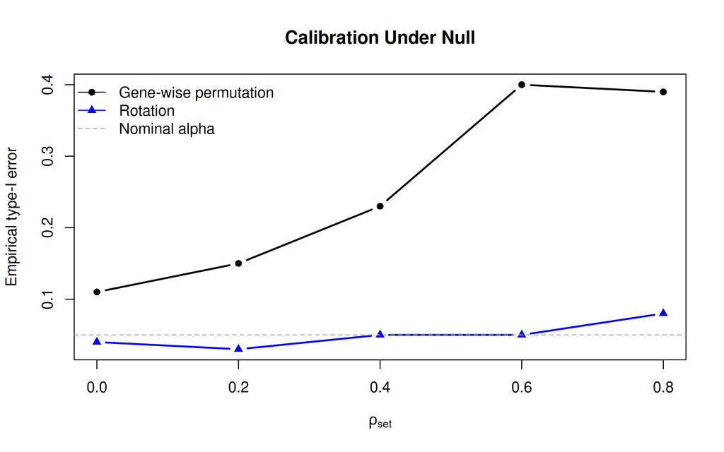

```r
plot_tbl <- summary_tbl[
  is.finite(summary_tbl$rho_set) &
    is.finite(summary_tbl$type1_perm) &
    is.finite(summary_tbl$type1_rot),
, drop = FALSE]
plot_tbl <- plot_tbl[order(plot_tbl$rho_set), , drop = FALSE]

if (nrow(plot_tbl) == 0) {
  plot.new()
  title("Calibration Under Null")
  text(0.5, 0.5, "No finite values to plot")
} else {
  y_lim <- range(c(plot_tbl$type1_perm, plot_tbl$type1_rot, alpha), na.rm = TRUE)
  if (y_lim[1] == y_lim[2]) y_lim <- y_lim + c(-0.01, 0.01)

  plot(
    plot_tbl$rho_set, plot_tbl$type1_perm,
    type = "b", pch = 16, lwd = 2,
    ylim = y_lim,
    xlab = expression(rho[set]),
    ylab = "Empirical type-I error",
    main = "Calibration Under Null"
  )
  lines(plot_tbl$rho_set, plot_tbl$type1_rot, type = "b", pch = 17, lwd = 2, col = "blue")
  abline(h = alpha, lty = 2, col = "darkgray")
  legend(
    "topleft",
    legend = c("Gene-wise permutation", "Rotation", "Nominal alpha"),
    col = c("black", "blue", "darkgray"),
    lty = c(1, 1, 2),
    pch = c(16, 17, NA),
    bty = "n"
  )
}
```

## 6.2 2. p-value ECDF comparison at low and high correlation

Uniformity under the null is a useful diagnostic. The dashed line is the ideal uniform ECDF.

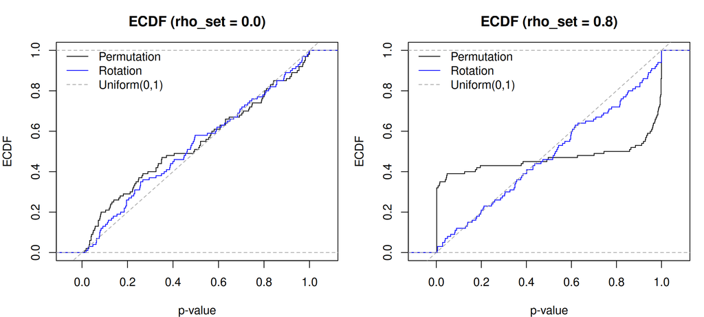

```r
par(mfrow = c(1, 2), mar = c(4, 4, 3, 1))

for (rho_val in c(min(rho_set_grid), max(rho_set_grid))) {
  idx <- results$rho_set == rho_val & is.finite(results$p_perm) & is.finite(results$p_rot)
  if (!any(idx)) {
    plot.new()
    title(sprintf("ECDF (rho_set = %.1f)", rho_val))
    text(0.5, 0.5, "No finite p-values")
  } else {
    plot(
      ecdf(results$p_perm[idx]),
      do.points = FALSE,
      verticals = TRUE,
      main = sprintf("ECDF (rho_set = %.1f)", rho_val),
      xlab = "p-value",
      ylab = "ECDF"
    )
    lines(ecdf(results$p_rot[idx]), do.points = FALSE, verticals = TRUE, col = "blue")
    abline(0, 1, lty = 2, col = "darkgray")
    legend(
      "topleft",
      legend = c("Permutation", "Rotation", "Uniform(0,1)"),
      col = c("black", "blue", "darkgray"),
      lty = c(1, 1, 2),
      bty = "n"
    )
  }
}
```

```r
par(mfrow = c(1, 1))
```

## 6.3 3. Example null distributions of the enrichment statistic

These panels compare the null distributions produced by the two methods for a single example dataset at low and high correlation.

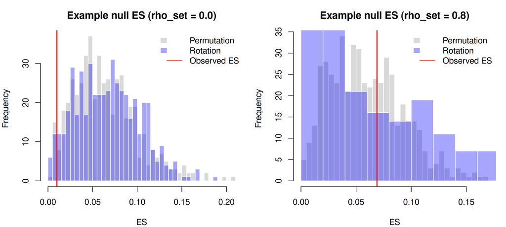

```r
par(mfrow = c(1, 2), mar = c(4, 4, 3, 1))

plot_example_null <- function(ex, rho_label) {
  if (is.null(ex)) {
    plot.new()
    title(sprintf("Example null ES (rho_set = %s)", rho_label))
    text(0.5, 0.5, "Not available")
    return(invisible(NULL))
  }
  hist(
    ex$null_perm, breaks = 40, col = "gray85", border = "white",
    main = sprintf("Example null ES (rho_set = %s)", rho_label),
    xlab = "ES"
  )
  hist(ex$null_rot, breaks = 40, col = rgb(0, 0, 1, 0.35), border = "white", add = TRUE)
  abline(v = ex$ES_obs, col = "red", lwd = 2)
  legend(
    "topright",
    legend = c("Permutation", "Rotation", "Observed ES"),
    fill = c("gray85", rgb(0, 0, 1, 0.35), NA),
    border = NA,
    lty = c(NA, NA, 1),
    col = c(NA, NA, "red"),
    bty = "n"
  )
}

ex_low <- example_distributions[[paste0("rho_", min(rho_set_grid))]]
ex_high <- example_distributions[[paste0("rho_", max(rho_set_grid))]]

plot_example_null(ex_low, sprintf("%.1f", min(rho_set_grid)))
plot_example_null(ex_high, sprintf("%.1f", max(rho_set_grid)))
```

```r
par(mfrow = c(1, 1))
```

# 7 Why Rotation Helps: Correlation Structure Preservation

The key idea is that rotation operates in the residual space and preserves the covariance/correlation structure more faithfully than gene-wise permutation.

## 7.1 4. Correlation heatmaps from the simulated datasets

These are the summary statistics generated by `rotations.r` from example datasets.

```r
if (file.exists("corr_heatmap_summary.csv")) {
  corr_heatmap_summary <- read.csv("corr_heatmap_summary.csv")
  knitr::kable(corr_heatmap_summary, digits = 4, caption = "Correlation heatmap summary statistics")
} else {
  cat("`corr_heatmap_summary.csv` not found. Re-run `rotations.r`.\n")
}
```

Correlation heatmap summary statistics

| rho_set | mean_within_set | mean_within_bg | mean_between |
| --- | --- | --- | --- |
| 0.0 | 0.0030 | 0.0945 | -0.0020 |
| 0.2 | 0.1382 | 0.0542 | 0.0483 |
| 0.4 | 0.3882 | 0.0740 | 0.0454 |
| 0.6 | 0.6255 | 0.0551 | 0.0039 |
| 0.8 | 0.7801 | 0.1414 | -0.0561 |

## 7.2 5. Rotation correlation-preservation metrics

This directly quantifies how similar the pairwise gene-gene correlations are before vs after a residual-space rotation.

```r
if (exists("rotation_preservation_summary")) {
  knitr::kable(rotation_preservation_summary, digits = 4, caption = "Rotation correlation-preservation summary")
} else if (file.exists("rotation_corr_preservation_summary.csv")) {
  rotation_preservation_summary <- read.csv("rotation_corr_preservation_summary.csv")
  knitr::kable(rotation_preservation_summary, digits = 4, caption = "Rotation correlation-preservation summary")
} else {
  cat("Rotation preservation summary not available.\n")
}
```

Rotation correlation-preservation summary

| rho_set | pairwise_corr_of_corr | mean_abs_diff | n_genes_plotted | n_pairs |
| --- | --- | --- | --- | --- |
| 0.0 | 1 | 0 | 400 | 79800 |
| 0.8 | 1 | 0 | 400 | 79800 |

## 7.3 6. Inline correlation-preservation visualization (original vs rotated)

The next chunk recreates the key idea visually for the lowest and highest `rho_set` example datasets:

- original gene-gene correlation heatmap
- rotated gene-gene correlation heatmap
- scatter of pairwise correlations (original vs rotated)

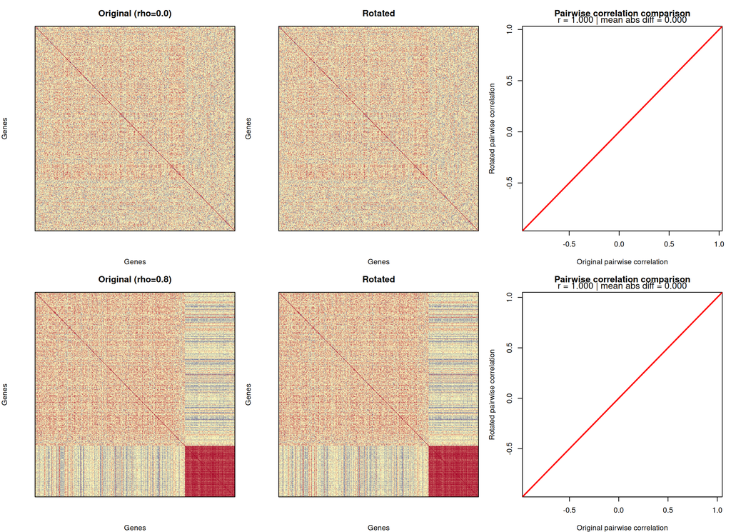

```r
plot_rotation_preservation_inline <- function(Y, set_idx, rho_val, bg_n = 300) {
  if (is.null(Y)) {
    plot.new()
    title(sprintf("rho_set = %.1f", rho_val))
    text(0.5, 0.5, "Example dataset not available")
    return(invisible(NULL))
  }

  nsamp <- ncol(Y)
  design0 <- matrix(1, nrow = nsamp, ncol = 1)
  fit0 <- limma::lmFit(Y, design0)
  Yhat0 <- fitted(fit0)
  res0 <- Y - Yhat0
  basis <- build_rotation_basis(design0 = design0, nsamples = nsamp)
  Rmat <- sample_rotation_matrix(basis)
  Y_rot <- Yhat0 + res0 %*% Rmat

  bg_idx <- setdiff(seq_len(nrow(Y)), set_idx)
  if (length(bg_idx) > bg_n) bg_idx <- sample(bg_idx, bg_n)
  keep_idx <- c(set_idx, bg_idx)

  corr_orig <- cor(t(Y[keep_idx, , drop = FALSE]))
  corr_rot <- cor(t(Y_rot[keep_idx, , drop = FALSE]))
  u <- upper.tri(corr_orig)
  x <- corr_orig[u]
  y <- corr_rot[u]
  r_xy <- suppressWarnings(cor(x, y, use = "complete.obs"))
  mad_xy <- mean(abs(x - y), na.rm = TRUE)

  cols <- colorRampPalette(c("#313695", "#ffffbf", "#a50026"))(100)

  image(
    seq_len(nrow(corr_orig)), seq_len(ncol(corr_orig)),
    corr_orig[nrow(corr_orig):1, ],
    col = cols, zlim = c(-1, 1), axes = FALSE,
    xlab = "Genes", ylab = "Genes",
    main = sprintf("Original (rho=%.1f)", rho_val)
  )
  box()

  image(
    seq_len(nrow(corr_rot)), seq_len(ncol(corr_rot)),
    corr_rot[nrow(corr_rot):1, ],
    col = cols, zlim = c(-1, 1), axes = FALSE,
    xlab = "Genes", ylab = "Genes",
    main = "Rotated"
  )
  box()

  plot(
    x, y,
    pch = 16, cex = 0.35,
    col = rgb(0, 0, 0, 0.18),
    xlab = "Original pairwise correlation",
    ylab = "Rotated pairwise correlation",
    main = "Pairwise correlation comparison"
  )
  abline(0, 1, col = "red", lwd = 2)
  mtext(sprintf("r = %.3f | mean abs diff = %.3f", r_xy, mad_xy), side = 3, line = 0.2, cex = 0.8)
}

par(mfrow = c(2, 3), mar = c(4, 4, 3, 1))
plot_rotation_preservation_inline(example_datasets[[paste0("rho_", min(rho_set_grid))]], set_idx, min(rho_set_grid))
plot_rotation_preservation_inline(example_datasets[[paste0("rho_", max(rho_set_grid))]], set_idx, max(rho_set_grid))
```

```r
par(mfrow = c(1, 1))
```

# 8 Interpretation Guide

When you read the report, the main differences to focus on are:

- **Type-I error calibration**:
  - if permutation inflates type-I error as `rho_set` increases, it suggests correlation is not being respected by the null
  - rotation should remain closer to nominal `alpha`
- **p-value ECDFs**:
  - departures from the diagonal under the null indicate miscalibration
- **Null ES histograms**:
  - compare how the null distributions differ in spread/shape
- **Correlation-preservation plots**:
  - points near the `y = x` line indicate rotated data preserve pairwise correlations well

# 9 Files Produced by `rotations.r`

```r
produced_files <- c(
  "simulation_cache.rds",
  "null_calibration_summary.csv",
  "null_calibration_results.csv",
  "null_calibration.pdf",
  "corr_heatmap_summary.csv",
  "rotation_corr_preservation_summary.csv"
)

file_status <- data.frame(
  file = produced_files,
  exists = file.exists(produced_files),
  stringsAsFactors = FALSE
)
knitr::kable(file_status, caption = "Key output files")
```

Key output files

| file | exists |
| --- | --- |
| simulation_cache.rds | TRUE |
| null_calibration_summary.csv | TRUE |
| null_calibration_results.csv | TRUE |
| null_calibration.pdf | TRUE |
| corr_heatmap_summary.csv | TRUE |
| rotation_corr_preservation_summary.csv | TRUE |

```r
cat("\nHeatmap PDFs:", length(Sys.glob("corr_heatmap_rho_*.pdf")), "\n")
```

```
##
## Heatmap PDFs: 5
```

```r
cat("Rotation-preservation PDFs:", length(Sys.glob("rotation_corr_preservation_rho_*.pdf")), "\n")
```

```
## Rotation-preservation PDFs: 2
```